# Analysis of Weather Event - Impact on Health and Economy

wonilChoi

## Reproducible research

### Peer-graded Assignment: Course Project 2

```r
suppressPackageStartupMessages({
    library(data.table)
    library(reshape2)
    library(ggplot2)
    library(R.utils)
    library(gridExtra)
})
setwd("D:\\R\\PeerAssignment_ReproducibleResearch")
```

## Synopsis

> This document explain how much each weather event cause harmful result. Data is from U.S. National Oceanic and Atmospheric Administration’s (NOAA) storm database start in the year 1950 and end in November 2011. Descriptive statistic is used to measure losses. The Most serious weather event regarding public health is tornado. Flood caused biggest economic cost.
- current time data downloaded : 13/08/2017 23:41
- data file name is ‘repdata%2Fdata%2FStormData.csv.bz2’. When data file is not exsist on getwd(), download and unzip it. To unzip bz2 file type, ‘R.utils’ package required. fread is fast read function in data.table package. raw data file is extracted to use fread function easily.

## Data process

```r
# data download when it doesn't exsist.
fileName <- "repdata%2Fdata%2FStormData.csv.bz2"
if (!fileName %in% list.files()) {
    fileUrl <- "https://d396qusza40orc.cloudfront.net/repdata%2Fdata%2FStormData.csv.bz2"
    download.file(fileUrl, fileName)
    bunzip2(filename = fileName, remove = FALSE)
}

# data read
raw_data <- fread(gsub(".bz2", "", fileName))
```

```
##
Read 0.0% of 967216 rows
Read 22.7% of 967216 rows
Read 40.3% of 967216 rows
Read 55.8% of 967216 rows
Read 72.4% of 967216 rows
Read 81.7% of 967216 rows
Read 92.0% of 967216 rows
Read 902297 rows and 37 (of 37) columns from 0.523 GB file in 00:00:10
```

```r
#pick columns to analyze on raw data.
sub_data <- raw_data[, .(EVTYPE, FATALITIES, INJURIES, PROPDMG, PROPDMGEXP, CROPDMG, CROPDMGEXP)]

# explore data checking unique values
uniqFun <- function(x) sub_data[,.GRP,by = eval(names(sub_data)[x])]
uniq_list <- lapply(1:length(sub_data), uniqFun)
uniq_list[c(1,5,7)]
```

```
## [[1]]
##                        EVTYPE GRP
##   1:                  TORNADO   1
##   2:                TSTM WIND   2
##   3:                     HAIL   3
##   4:            FREEZING RAIN   4
##   5:                     SNOW   5
##  ---
## 981:          LAKESHORE FLOOD 981
## 982: MARINE THUNDERSTORM WIND 982
## 983:       MARINE STRONG WIND 983
## 984:    ASTRONOMICAL LOW TIDE 984
## 985:         VOLCANIC ASHFALL 985
##
## [[2]]
```

[output cut: 32 more lines]

```r
# the other no special on unique value
# There are lots of levels on EVTYPE as factor , so investigate more
(ev_tab <- sort(table(sub_data$EVTYPE), decreasing = TRUE))[1:10]
```

```
##
##               HAIL          TSTM WIND  THUNDERSTORM WIND
##             288661             219940              82563
##            TORNADO        FLASH FLOOD              FLOOD
##              60652              54277              25326
## THUNDERSTORM WINDS          HIGH WIND          LIGHTNING
##              20843              20212              15754
##         HEAVY SNOW
##              15708
```

```r
EVTYPE_prop <- sum(head(ev_tab,10))/dim(sub_data)[1]
(EVTYPE_prop <- sprintf("%.0f%%", 100 * EVTYPE_prop))
```

```
## [1] "89%"
```

```r
# top 10 EVTYPE proportion - 89%

# change character scale into numerical scale
sub_data[, PROPDMGSCALE := 1e0]
sub_data[PROPDMGEXP %in% c("K"), PROPDMGSCALE := 1e3]
sub_data[PROPDMGEXP %in% c("H","h"), PROPDMGSCALE := 1e2]
sub_data[PROPDMGEXP %in% c("M","m"), PROPDMGSCALE := 1e6]
sub_data[PROPDMGEXP %in% c("B","b"), PROPDMGSCALE := 1e9]

sub_data[, CROPDMGSCALE := 1e0]
sub_data[CROPDMGEXP %in% c("K","k"), CROPDMGSCALE := 1e3]
sub_data[CROPDMGEXP %in% c("M","m"), CROPDMGSCALE := 1e6]
sub_data[CROPDMGEXP %in% c("B"), CROPDMGSCALE := 1e9]

## comparing before and after
# sub_data[, .(PROPSCALE_N = .N), by = PROPDMGSCALE]
# head(sub_data[, .(PROPEXP_N = .N), by = PROPDMGEXP])
# sub_data[, .(CROPSCALE_N = .N), by = CROPDMGSCALE]
# head(sub_data[, .(CROPEXP_N = .N), by = CROPDMGEXP])
```

- First, I checked whethere data is ready for analysis. EVTYPE, our important variable has many similar elements such as “ICE ROADS” and “SNOW/ICE”. However, top 10 EVTYPE account for 89%, so remainer ignored considering less importance.
- FATALITY and INJURIES are nothing to change.
- PROPDMG, CROPDMG variable are actually consisted of 2 columns - DMG DMGEXP - which must be transformed into numeric data. When changing DMGEXP into numeric, some vague rows such as + and integer are ignored, and results are fine comparing tables counting PROPDMGEXP - its influence under 0.1%. Finally, PROP_LOSS = PROPDMGSCALE PROPDMG, CROP_LOSS = CROPDMGSCALE CROPDMG.

## Result

### Across the United States, which types of events (as indicated in the EVTYPE variable) are most harmful with respect to population health?

```r
# make table for plot
HEALTH_table <-
    sub_data[,list(FATAL = sum(FATALITIES),
                   INJUR = sum(INJURIES),
                   TOTAL = sum(FATALITIES, INJURIES),
                   COUNT = .N),
             by = EVTYPE][order(-TOTAL)][1:8]
HEALTH_table
```

```
##            EVTYPE FATAL INJUR TOTAL  COUNT
## 1:        TORNADO  5633 91346 96979  60652
## 2: EXCESSIVE HEAT  1903  6525  8428   1678
## 3:      TSTM WIND   504  6957  7461 219940
## 4:          FLOOD   470  6789  7259  25326
## 5:      LIGHTNING   816  5230  6046  15754
## 6:           HEAT   937  2100  3037    767
## 7:    FLASH FLOOD   978  1777  2755  54277
## 8:      ICE STORM    89  1975  2064   2006
```

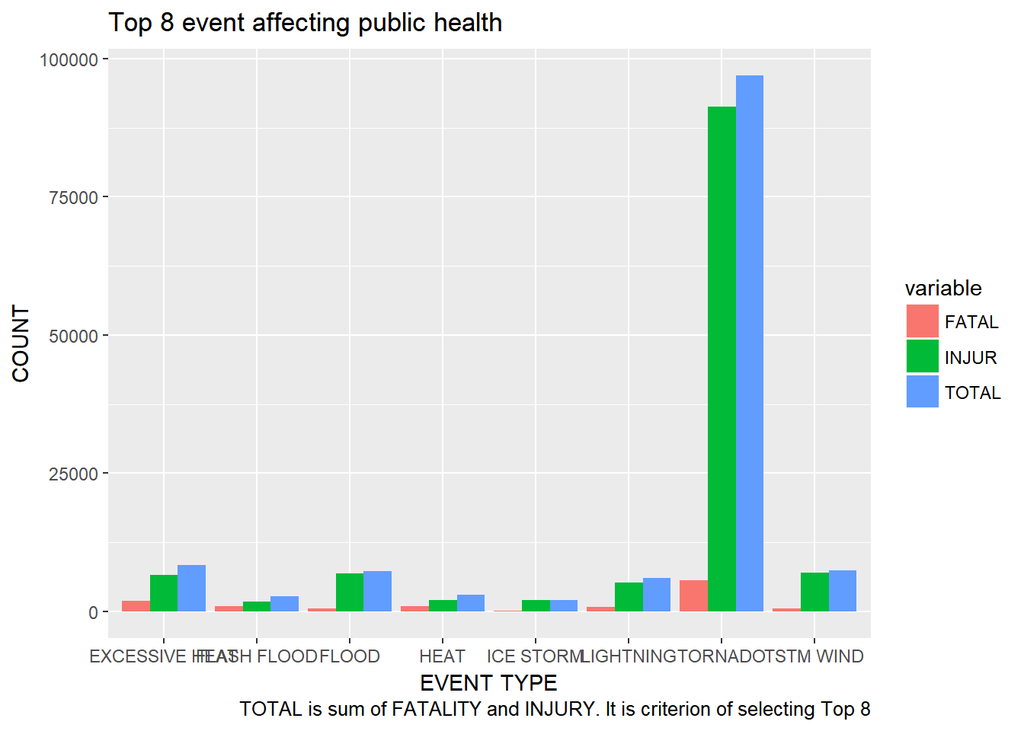

```r
HEALTH_table <- melt(HEALTH_table, id.vars = 1, measure.vars = c(2,3,4))

HEALTH_plot <- ggplot(HEALTH_table, aes(x = EVTYPE, y = value, fill = variable)) +
    geom_col(position = "dodge") +
    labs(x = "EVENT TYPE",
        y = "COUNT",
        caption = "TOTAL is sum of FATALITY and INJURY. It is criterion of selecting Top 8",
        title = "Top 8 event affecting public health"
    )
HEALTH_plot
```

### Across the United States, which types of events have the greatest economic consequences?

```r
tmp <- sub_data[, list(PROP_LOSS = PROPDMGSCALE * PROPDMG, CROP_LOSS = CROPDMGSCALE * CROPDMG), by = EVTYPE]

ECONO_table <-
    tmp[,list(PropertyLoss = sum(PROP_LOSS),
                   CropLoss = sum(CROP_LOSS),
                   TOTAL = sum(PROP_LOSS, CROP_LOSS),
                   COUNT = .N),
             by = EVTYPE][order(-TOTAL)][1:8]
ECONO_table
```

```
##               EVTYPE PropertyLoss    CropLoss        TOTAL  COUNT
## 1:             FLOOD 144657709807  5661968450 150319678257  25326
## 2: HURRICANE/TYPHOON  69305840000  2607872800  71913712800     88
## 3:           TORNADO  56937160779   414953270  57352114049  60652
## 4:       STORM SURGE  43323536000        5000  43323541000    261
## 5:              HAIL  15732267543  3025954473  18758222016 288661
## 6:       FLASH FLOOD  16140812067  1421317100  17562129167  54277
## 7:           DROUGHT   1046106000 13972566000  15018672000   2488
## 8:         HURRICANE  11868319010  2741910000  14610229010    174
```

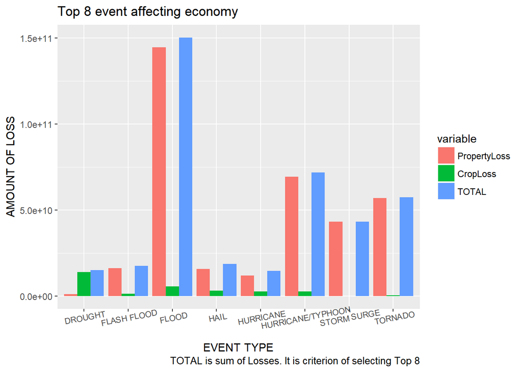

```r
ECONO_table <- melt(ECONO_table, id.vars = 1, measure.vars = c(2,3,4))

ECONO_plot <- ggplot(ECONO_table, aes(x = EVTYPE, y = value, fill = variable)) +
    geom_col(position = "dodge") +
    theme(axis.text.x = element_text(angle = 11, size = 8)) +
    labs(x = "EVENT TYPE",
        y = "AMOUNT OF LOSS",
        caption = "TOTAL is sum of Losses. It is criterion of selecting Top 8",
        title = "Top 8 event affecting economy"
    )
ECONO_plot
```